# Investment curves

Matheus, in your 2018 paper with Aditya Maheshwari, you estimated the capital accumulation rate (a constant), which you denoted $k$, for the Goodwin model. In this model, you had $\dot{K} = k \Pi - \delta K$, where $\Pi = Y - wL$. For OECD countries, you found that $k$ ranged between 0.6 and 0.8.

We now have a more complex model, where in particular $\dot{K} = \kappa(\pi) Y - \delta K$.

You indicated to me that you thought the investment curve used by AFD (Bovari et al., 2018) was too conservative. It is:

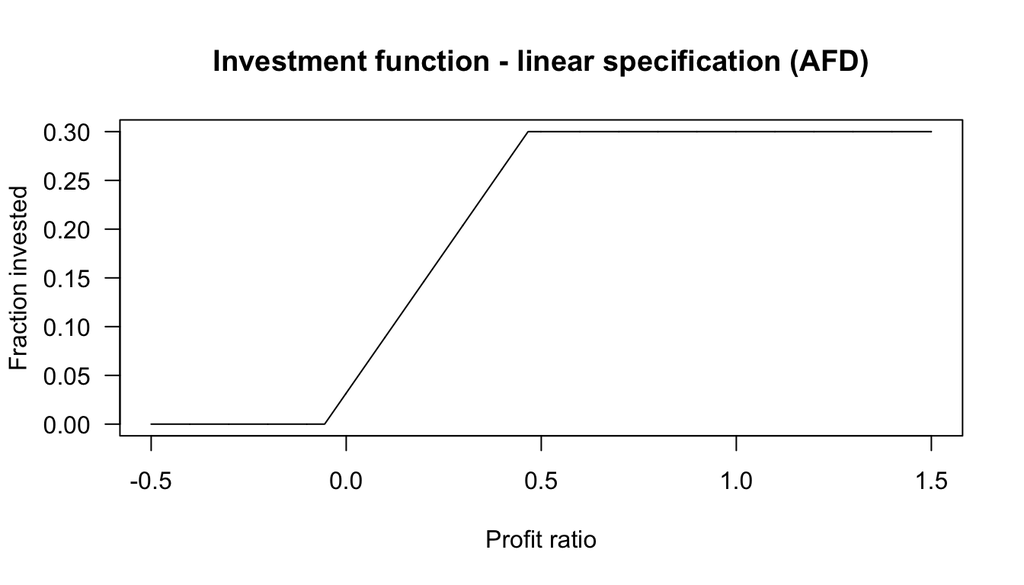

where the parameters are

```r
  ### Investment function
  # linear
  I_lin_constant = 0.0318,         # Bovari et al. (2018b)
  I_lin_slope    = 0.5753,         # Bovari et al. (2018b)
  I_lin_max      = 0.3,            # Bovari et al. (2018b)
  I_lin_min      = 0,              # Bovari et al. (2018b)
```

which does seem too low. I constructed a bunch of different investment functions and ran them all. I was getting some funny results for the investment to profits ratio, which I had as $\frac{I}{\Pi} = \frac{\kappa(\pi)Y}{\Pi}$. Upon further reflection, I think that the appropriate ratio is actually $\frac{pI}{\Pi} = \frac{\kappa(\pi) p Y}{\Pi}$. This divides nominal investment by nominal profits. The confusing part was that the investment curve isn’t actually computing the fraction of profits invested, as one can see below. In fact, as I show below, the AFD linear curve returns a nominal investment to profit share that is well within the range estimated by Grasselli and Maheshwari (2018).

First, I reiterate the profit and investment mechanisms:

Total profits:
$$\Pi := p Y - w L - \delta_{\mathbf{D}^K} p K - r D + p \Upsilon$$

Profit share:
$$\pi := \frac{\Pi}{p Y}$$

Dividends and retained earnings:
$$\Pi_{d} := \Delta(\pi) p Y \\
\Pi_{r} := \Pi - \Pi_{d}$$

Real investment:
$$I := \kappa(\pi) Y$$

where the investment function $\kappa(\pi)$ is function under discussion. The result $\kappa(\pi) \in [0,1]$ returns the fraction of (real) output invested.

Debt dynamics:
$$\dot{D} := p (I - \delta_{\mathbf{D}^K} K) - \Pi_{r}$$

Capital dynamics:

$$\dot{K} := I - \delta_{\mathbf{D}^K} K$$

# Exploring investment dynamics

I will explore the investment dynamics with three different scenarios. The scenarios are given by the following initial conditions. The first one uses the initial conditions estimated by AFD (Bovari et al., 2018).

```r
IC_1 <- c(
  # Economic variables
  Y_N       =  30,       # global GDP, in trillions of USD
  d_N       =  1.5,      # private debt ratio of the economy
  lambda_N  =  0.67,     # employment rate of the global economy
  omega_N   =  0.58,     # wage share of the economy
  N_N       =  2.4,      # Workforce of the (world) economy, in billions /2
  g_sigma_N =  -0.0105,  # Growth rate of the emissions intensity of the economy
  n_N       =  0.03,     # Emissions reduction rate
  E_ind_N   =  18,       # Industrial CO2-e emissions, in Gt CO2-e

  # Climate variables - unchanged in all scenarios
  CO2_AT   =  851,      # CO2-e concentration in the atmosphere layer, in Gt C
  CO2_UP   =  460,      # CO2-e concentration in the biosphere and upper ocean layer, in Gt C
  CO2_LO   =  1740,     # CO2-e concentration in the deep ocean layer, in Gt C
  E_land   =  2.6,      # Exogenous land use change CO2-e emissions, in Gt CO2-e
  p        =  1,        # Composite good price level
  p_BS     =  547.22,   # Backstop technology price level
  Temp     =  0.85,     # Temperature in the atmosphere, biosphere, and upper ocean layer, in degrees Celsius
  Temp_LO  =  0.0068    # Temperature in the deep ocean layer, in degrees Celsius
)
```

In the second scenario, I make the initial conditions more favourable.

```r
IC_2 <- c(
  # Economic variables
  Y_N       =  40,       # changed
  d_N       =  0.6,      # changed
  lambda_N  =  0.9,      # changed
  omega_N   =  0.6,      # changed
  N_N       =  2.4,
  g_sigma_N =  -0.0105,
  n_N       =  0.03,
  E_ind_N   =  18,

  # Climate variables - unchanged in all scenarios
  CO2_AT   =  851,
  CO2_UP   =  460,
  CO2_LO   =  1740,
  E_land   =  2.6,
  p        =  1,
  p_BS     =  547.22,
  Temp     =  0.85,
  Temp_LO  =  0.0068
)
```

In the third scenario, the initial conditions are worse than the AFD conditions:

```r
IC_3 <- c(
  # Economic variables
  Y_N       =  20,       # changed
  d_N       =  2,        # changed
  lambda_N  =  0.5,      # changed
  omega_N   =  0.45,
  N_N       =  2.4,
  g_sigma_N =  -0.0105,
  n_N       =  0.03,
  E_ind_N   =  18,

  # Climate variables - unchanged in all scenarios
  CO2_AT   =  851,
  CO2_UP   =  460,
  CO2_LO   =  1740,
  E_land   =  2.6,
  p        =  1,
  p_BS     =  547.22,
  Temp     =  0.85,
  Temp_LO  =  0.0068
)
```

Running the three scenarios from above gives the following:

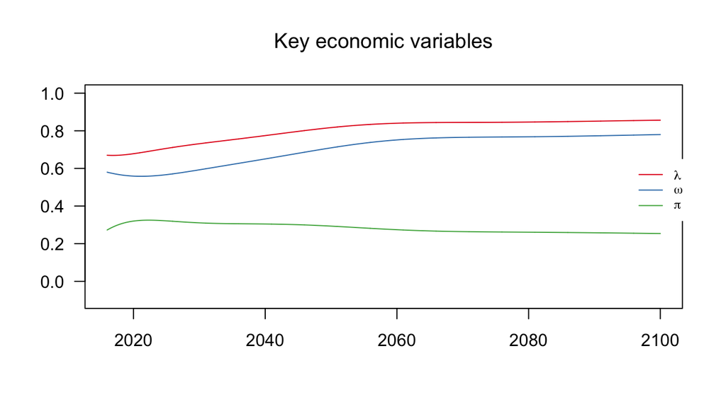

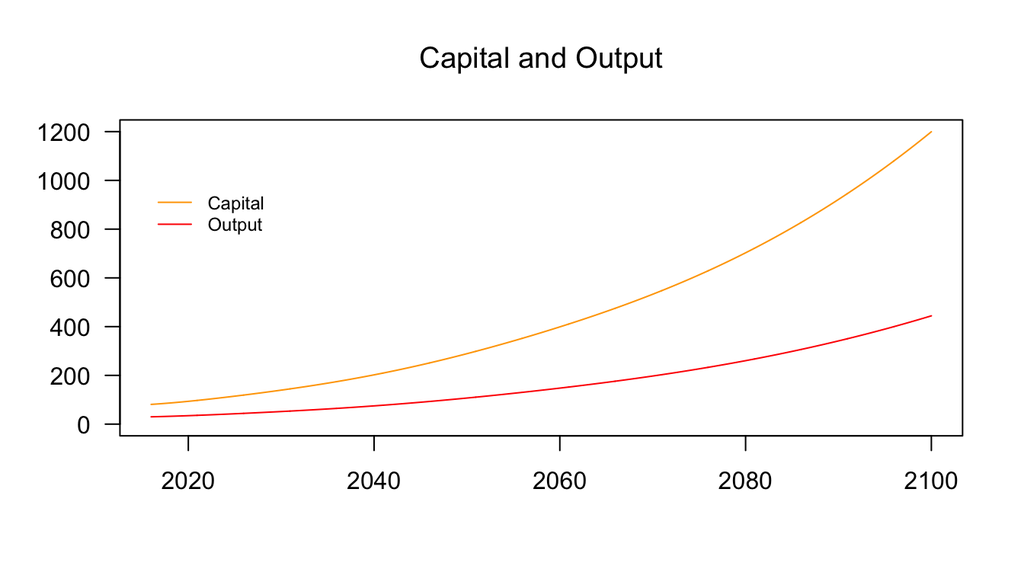

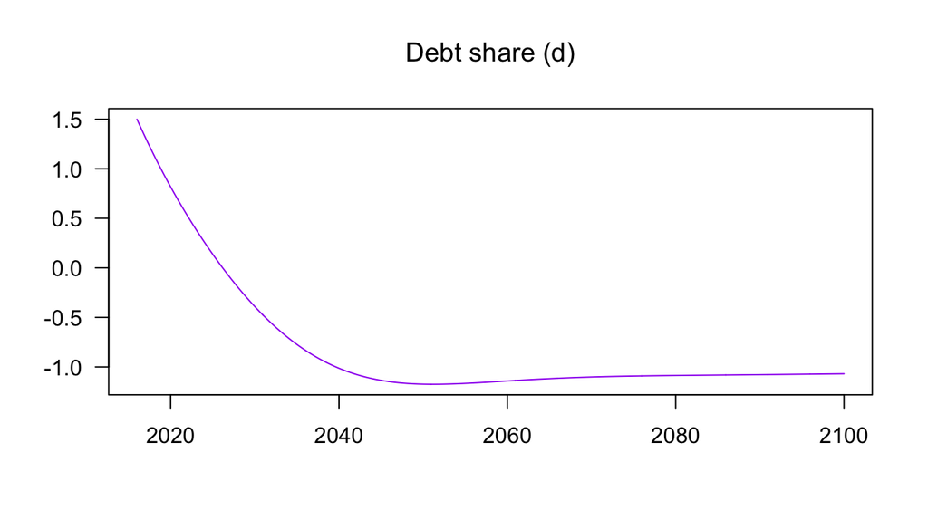

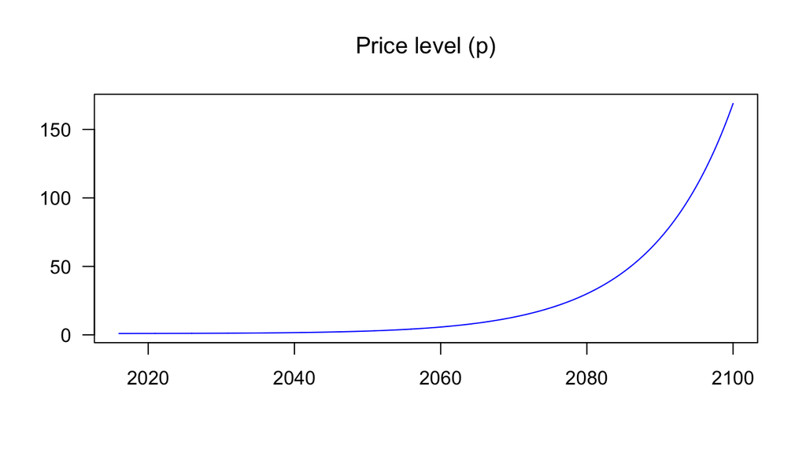

```r
# Set up simulation
Time <- c(
  start         =     2016,
  end           =     2100,
  step          =     0.05,
  start_p_Car_N =     2016
)

Active <- list(
  Damage_N     =   'None',       # None / Nordhaus / Weitzman / Stern
  Damage_K     =    0,           # Fraction of damages allocated to capital
  Temperature  =    TRUE,        # T / F
  Lab_Prod_N   =   'constant',   # constant / Burke
  p_Car_N      =   'None',       # None / Low / Medium / High / Canada
  s_A_N        =   0,            # fraction of abatement costs subsidized by government
  Phillips     =   'linear',     # linear / asymptotic
  Invest       =   'linear'      # linear / arctan
)

#================================================================================
## Run a scenario
# Initial conditions from Bovari et al. (2018) (Y=30, d=1.5, lambda=0.67, omega=0.58)
Simulation1 <- simulation(time             = Time,
                          init_sim         = IC_1,
                          pars             = Pars,
                          active           = Active,
                          method           = 'lsoda',
                          show_end_results = FALSE,
                          show_graph       = T
)
```

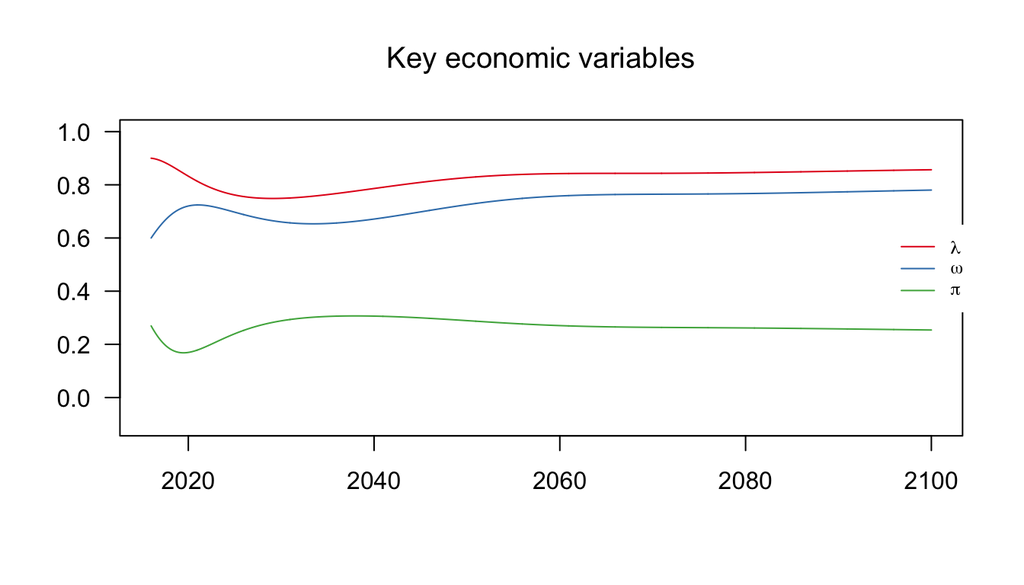

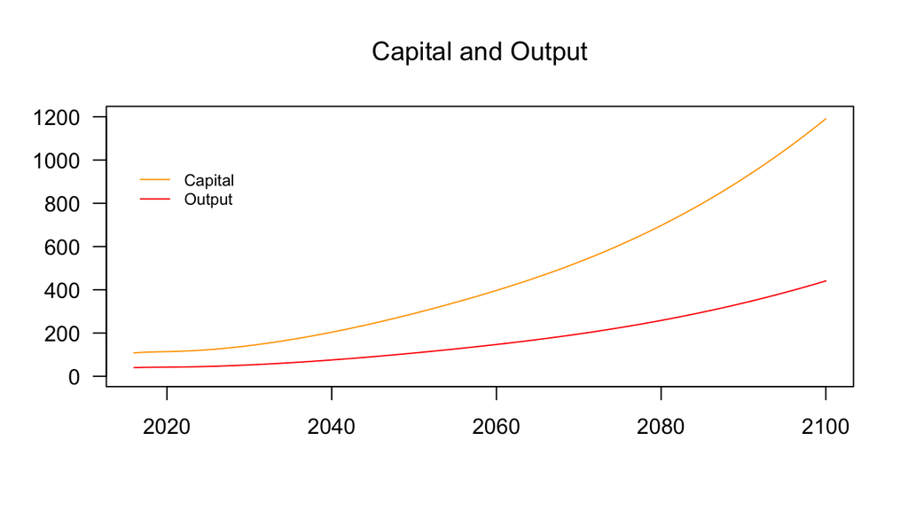

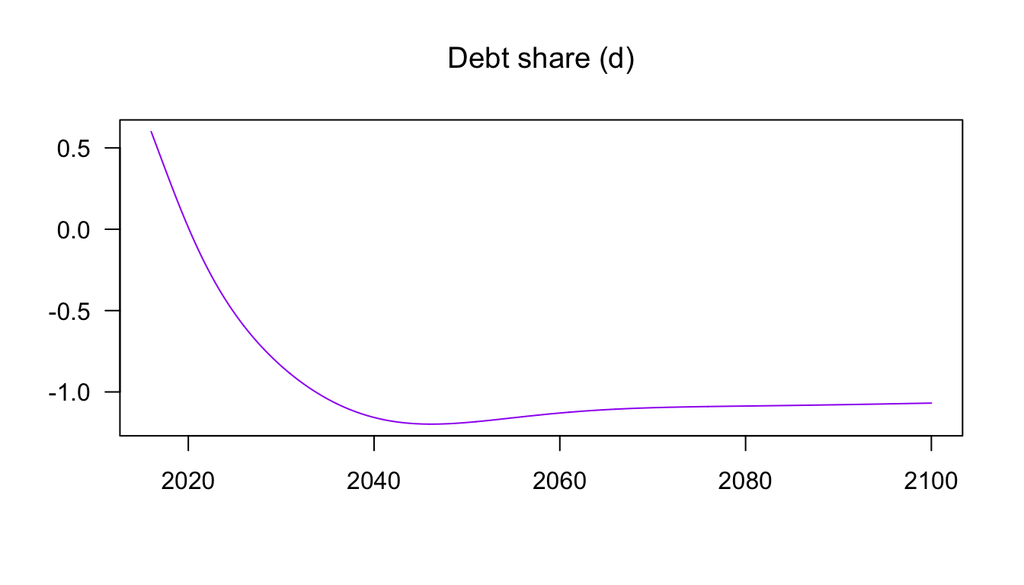

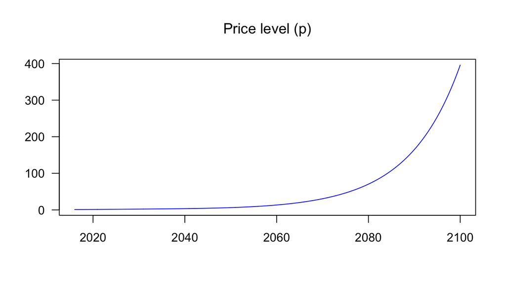

```r
# low debt share, high employment (Y=40, d=0.6, lambda=0.9, omega=0.6)
Simulation2 <- simulation(time             = Time,
                          init_sim         = IC_2,
                          pars             = Pars,
                          active           = Active,
                          method           = 'lsoda',
                          show_end_results = FALSE,
                          show_graph       = T
)
```

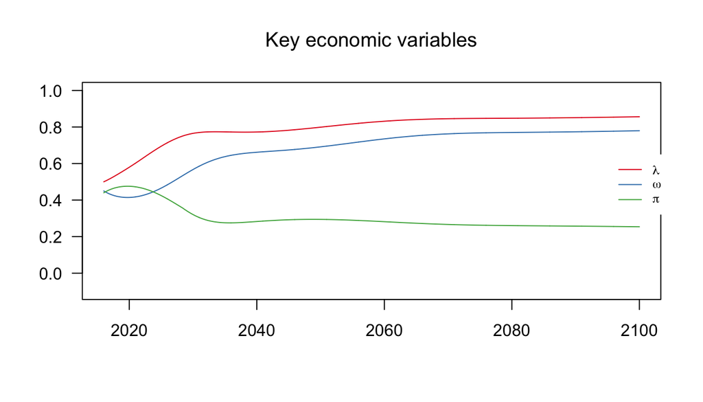

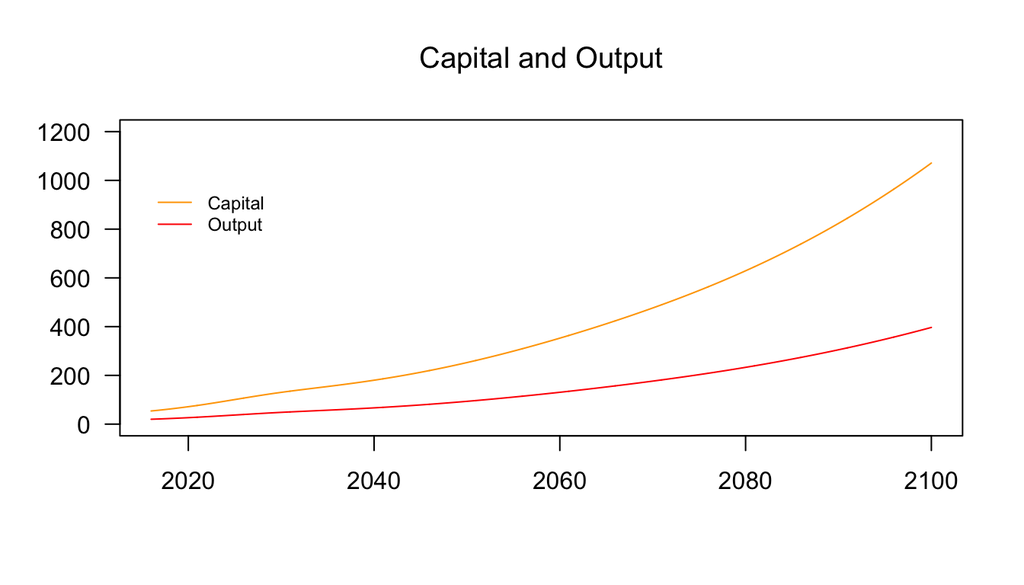

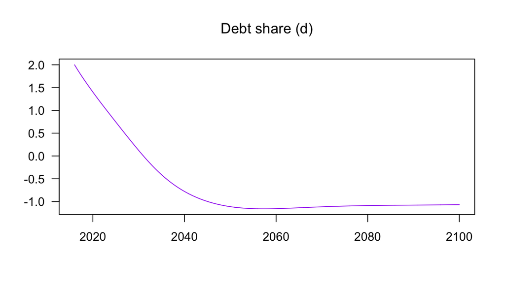

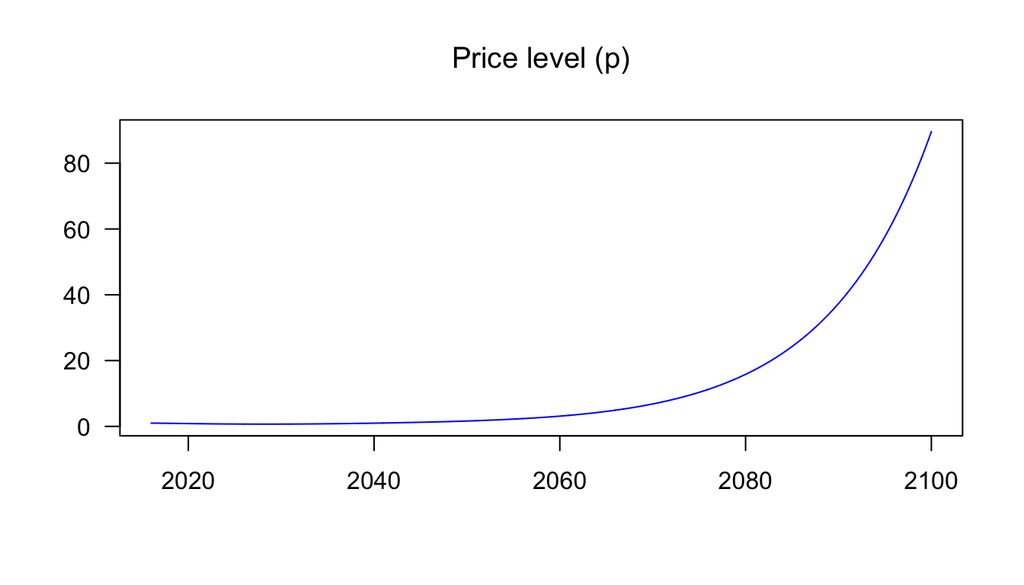

```r
# high debt share, low employment (Y=20, d=2, lambda=0.5, omega=0.45)
Simulation3 <- simulation(time             = Time,
                          init_sim         = IC_3,
                          pars             = Pars,
                          active           = Active,
                          method           = 'lsoda',
                          show_end_results = FALSE,
                          show_graph       = T
)
```

It is worth noting that with this specification the model doesn’t approach the bad equilibrium even with very poor initial conditions (ex. d=5, lambda=0.4, Y=5). This is true with both the linear and non-linear Phillips curve.

## Linear investment curve - AFD

First, I use the linear investment specification from AFD (Bovari et al., 2018). The parameters for the investment curve are:

```r
  ### Investment function
  # linear
  I_lin_constant = 0.0318,         # Bovari et al. (2018b)
  I_lin_slope    = 0.5753,         # Bovari et al. (2018b)
  I_lin_max      = 0.3,            # Bovari et al. (2018b)
  I_lin_min      = 0,              # Bovari et al. (2018b)
```

which gives the following investment curve:

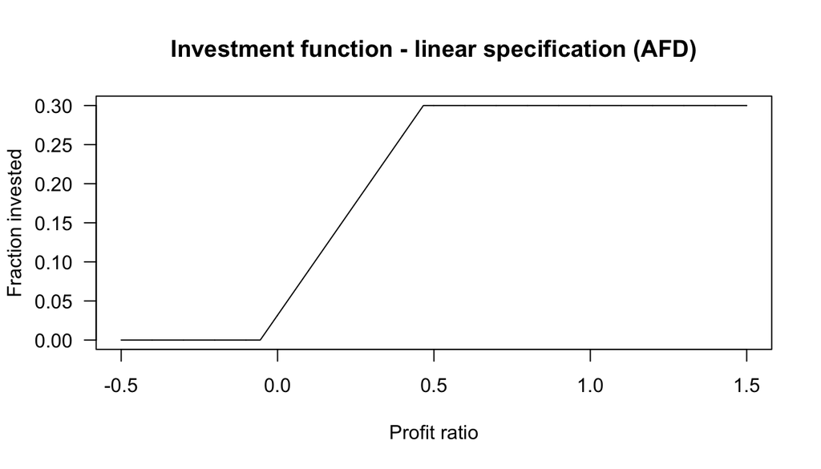

Since investment is a function of the profit share, it is worth plotting the profit share ($\pi = \frac{\Pi}{pY}$) for each scenario.

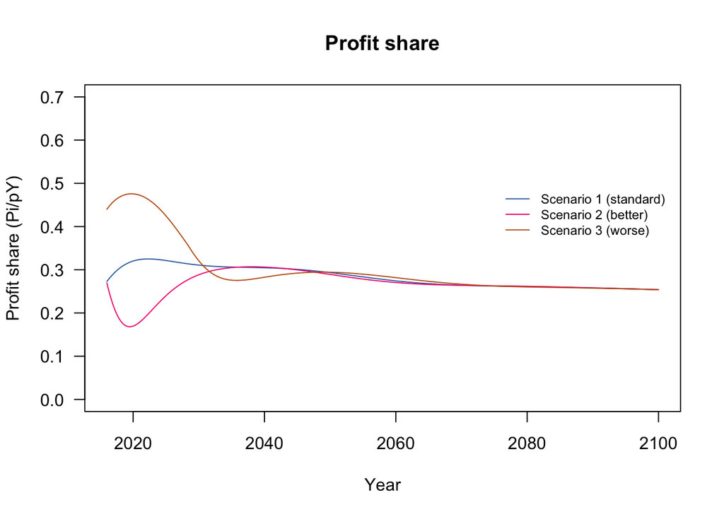

Now we consider what happens with the fraction of total profits invested (ie $\frac{pI}{\Pi}$) in the different scenarios.

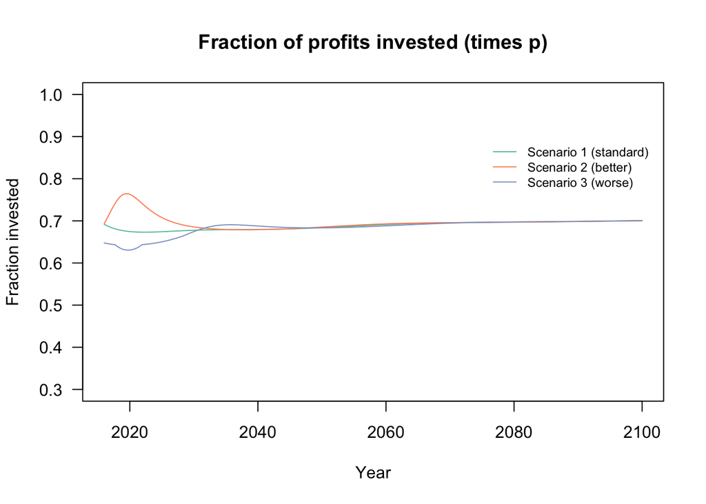

We see that in all three scenarios the nominal investment to profit rate normalizes at about 70%, well within the range estimated by Grasselli and Maheshwari (2018).

We can also look at the investment to output ratio ($I/N$). I looked at data from the World Bank, and the world median is around 20%. As you can see below, that’s what the model returns with this investment curve.

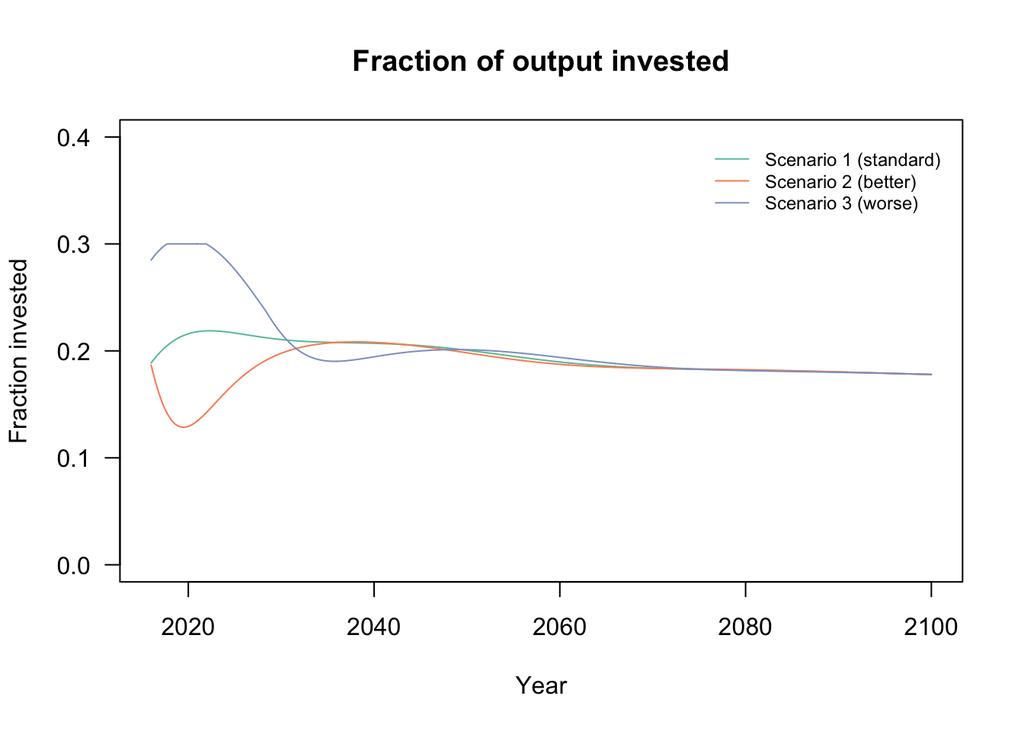

So it is no longer clear to me that the investment curve estimated by AFD (Bovari et al., 2018) is underestimating investment. If this is the case, then there must be another reason for strange dynamics.

## Arctan investment curve - original

Despite the fact that I no longer am certain that the AFD curve returns low investment, it could still be better to use a nonlinear investment curve. I first implement the one from Grasselli et al. (2014).

```r
  # arctan
  kappa_0        = 0.5,            # Costa Lima et al. (2014)
  kappa_1        = 0.31831,        # Costa Lima et al. (2014)
  kappa_2        = 63.989,         # Costa Lima et al. (2014)
  kappa_3        = -11.991,        # Costa Lima et al. (2014)
```

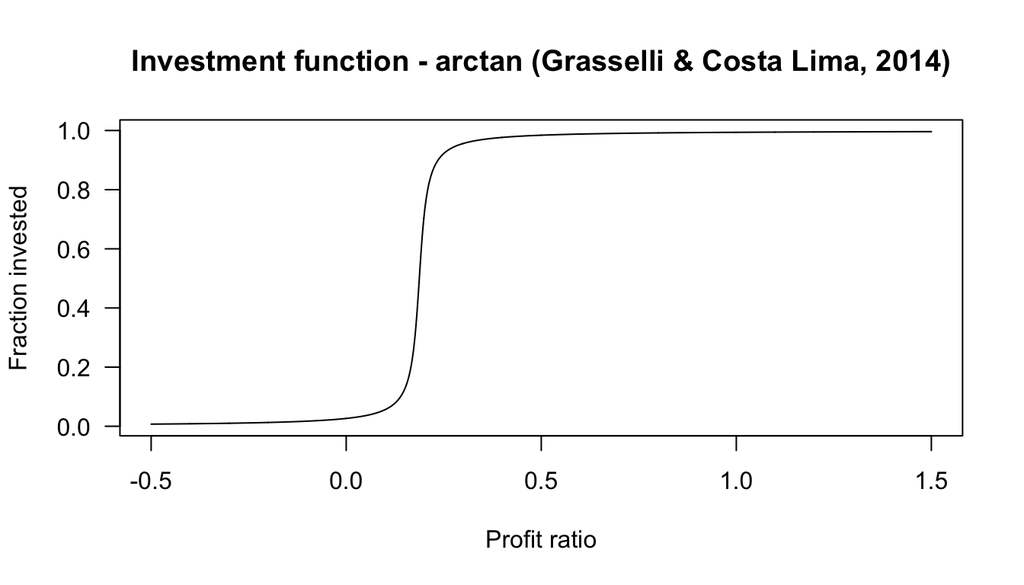

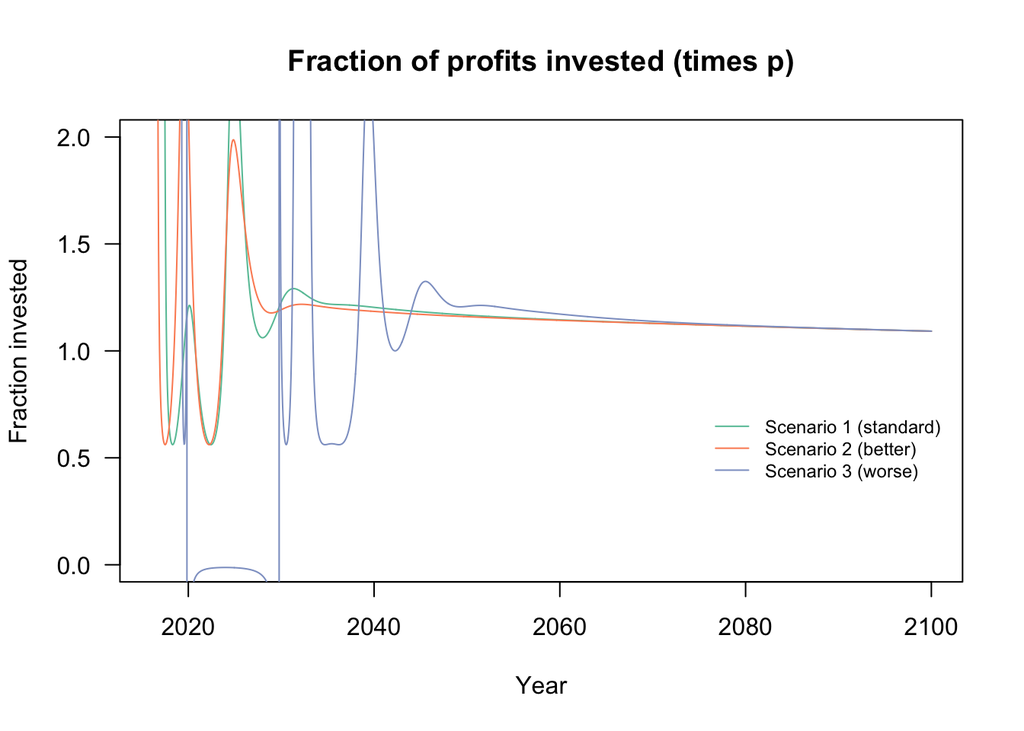

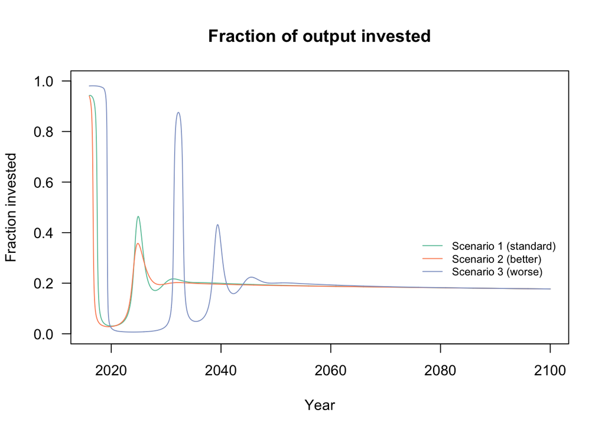

So it is clear why this curve was not working when implemented naively, even though in the paper (Grasselli et al., 2014) $\kappa(\pi)$ is a fraction of output ($Y$).

## Alternative arctan investment curves

Below I try to create an arctan investment curve with similar properties to the linear one.

```r
Pars['kappa_2'] = 20
Pars['kappa_3'] = -10
```

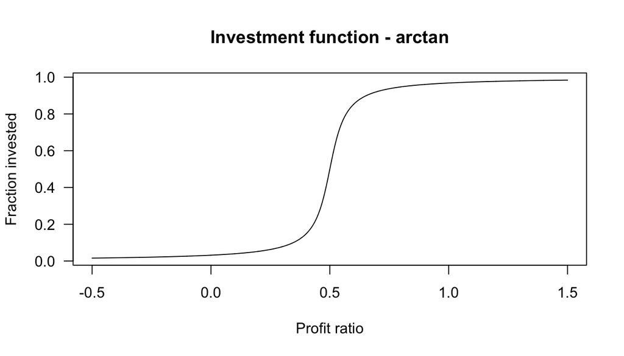

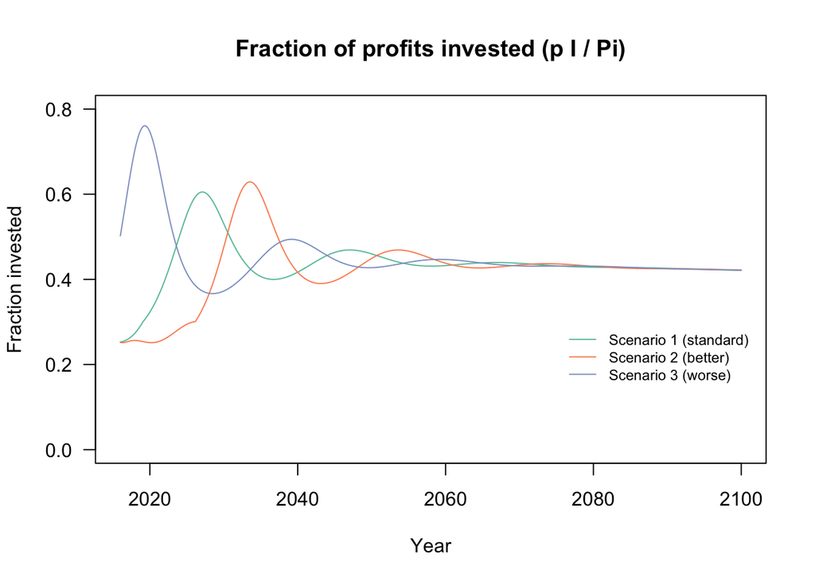

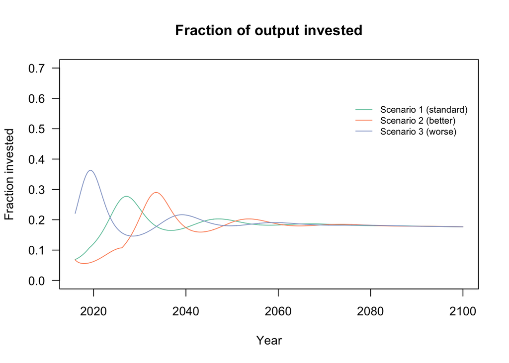

This investment curve avoids any large spikes in investment for these scenarios, but the investment to profits ratio equilibrates a bit too low to be in line with the estimates from Grasselli and Maheshwari (2018).

Another arctan curve is:

```r
Pars['kappa_2'] = 15
Pars['kappa_3'] = -6
```

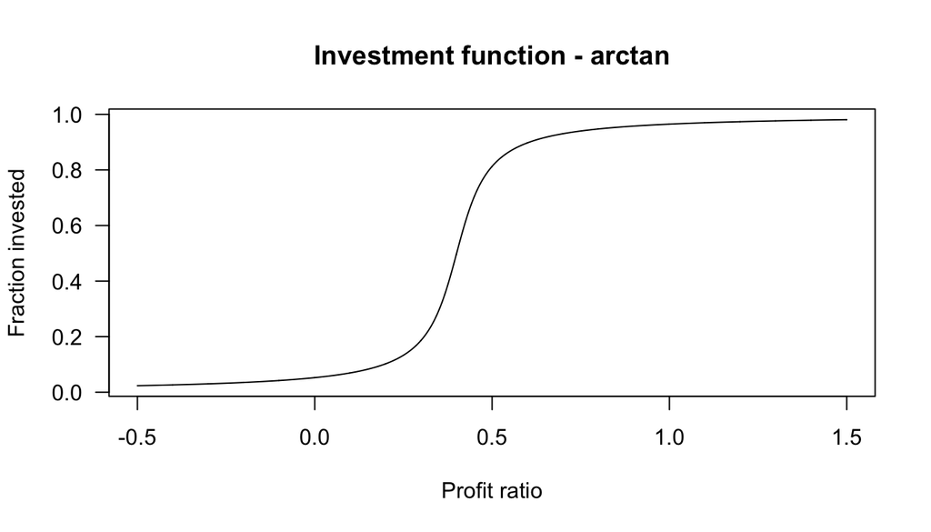

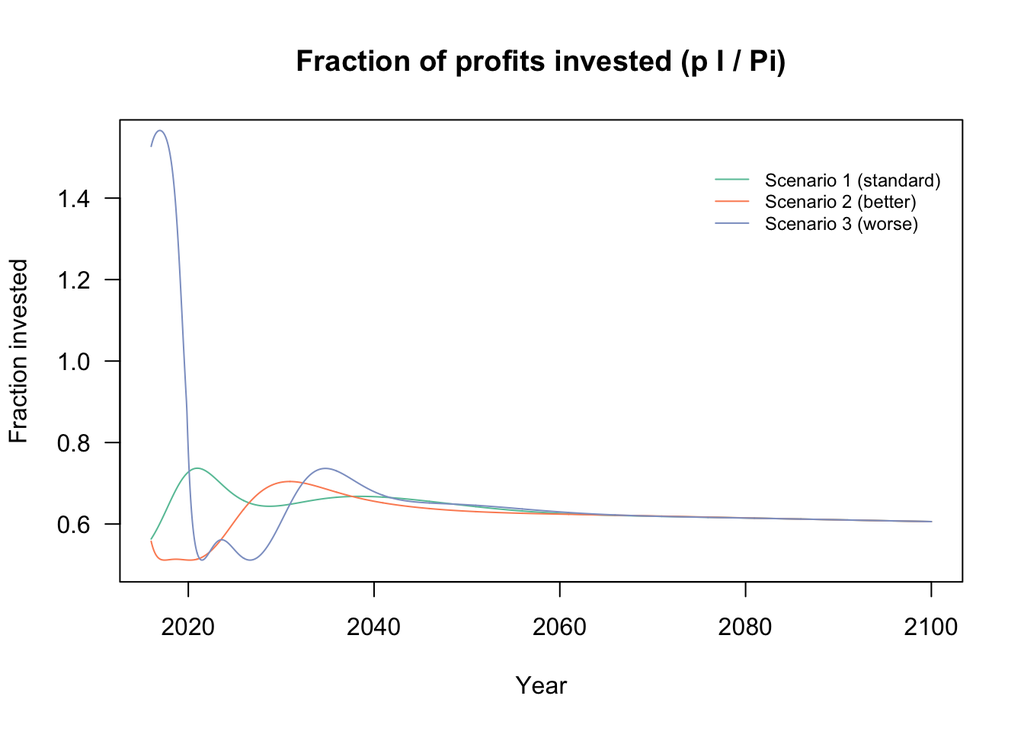

With this arctan investment function, the investment to profit ratio normalizes around 0.6, as with the linear AFD specification, though it is a bit more sensitive to higher profit shares.

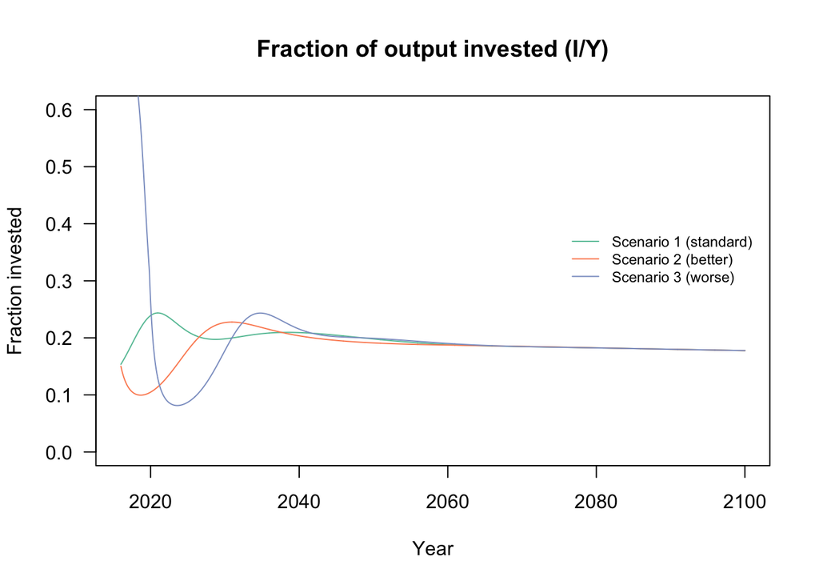

I’m not sure what the right arctan curve is. I played with several curves. There is a trade-off because having higher investment at equilibrium means in is more likely for investment to spike up (though perhaps this is desirable). We can talk about what the right arctan investment curve is. However, if both the linear AFD curve and the arctan curve I create return a nominal investment to nominal profits ratio of about 0.6-0.7, then switching the curve will not change the dynamics of the model much. As is shown before, the results for the debt share in the three scenarios is nearly the same as with the linear curve:

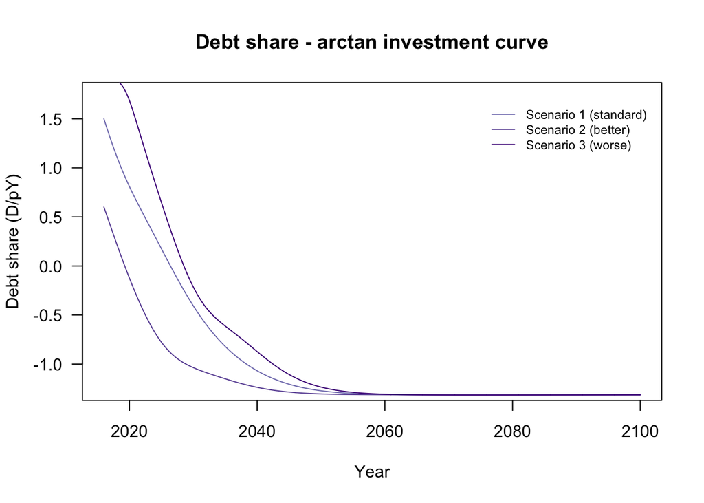

# Dividends

This leads me back to thinking that the culprit is dividends. As I noted before, the dividends curve used by Mc Isaac in the code he sent caused dividends to be very high. The two papers by Bovari et al. use two different dividend functions. The functions are different enough that they have significantly different impacts on the amount of dividends payed, and on the debt share $d$, as shown before. The results with the “Coping with collapse” (Bovari et al., 2018a) dividends specification are shown in magenta, while the results with the “Debt and damages” (Bovari et al., 2018b) dividends specification are shown in purple.

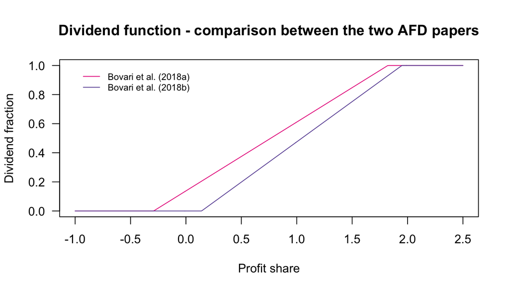

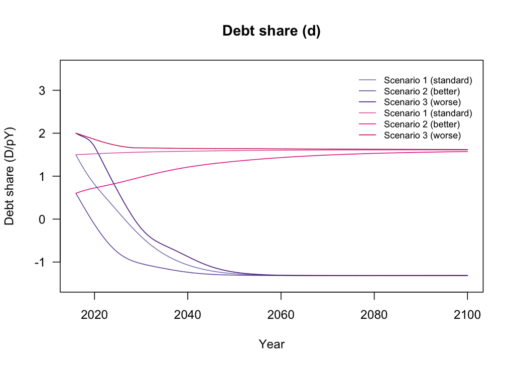

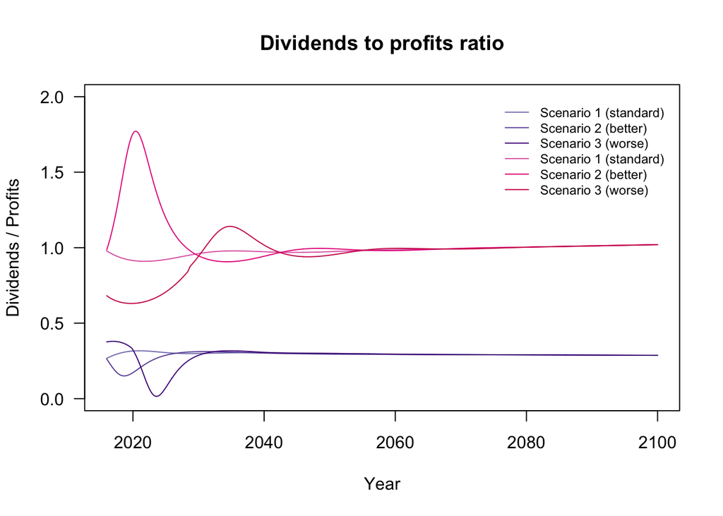

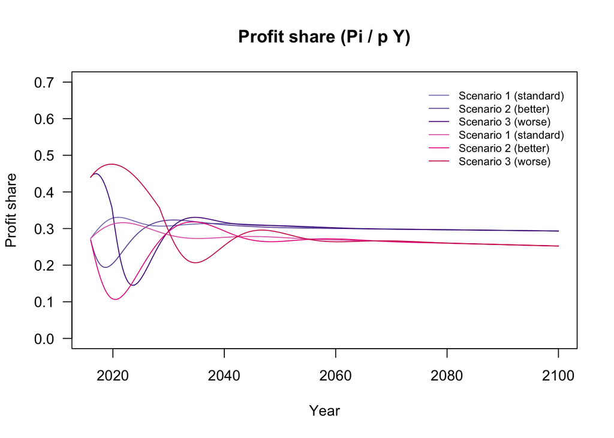

In comparison to AFD, my model seems to have lower debt because of dividends (and not investment). Perhaps the team at AFD had problems with dividends too, given that they used multiple dividends specifications, and also tried having dividends be a function of this $\pi_k = \frac{\Pi}{p K}$. Since this problem still exists when we remove dividends (and make the debt gradient depend on total profits), perhaps profits are too high? Because it does not make sense to me to have firms pay out all (or more!) of their profits as dividends, unless we want to remove the concept of dividends entirely and assume all profits are distributed to consumers. Perhaps wages or prices aren’t high enough?